# Factors Influencing Prosper Loan

## By: Mohammed Mahmud Katun

## Investigation Overview

> The focus of this investigation is to look at those factors that affect proper loans, the category of borrowers and the purpose for which they use the loan. Here, I will look at Employment status, Income Verifiable, Credit Score borrower APR, Term of repayment, loan application date, borrowers category (Occupation) and listing category.

## Dataset Overview

> This dataset (prosperLoanData) is a financial dataset for loan processing. It is related to the loan, borrowers, lenders, interest rate and other information required from borrowers. It contains 113,937 loans with 81 variables. 29,084 variables were removed from the analysis due to missing values and non relevance to my focus.

## Employment Status of Borrowers

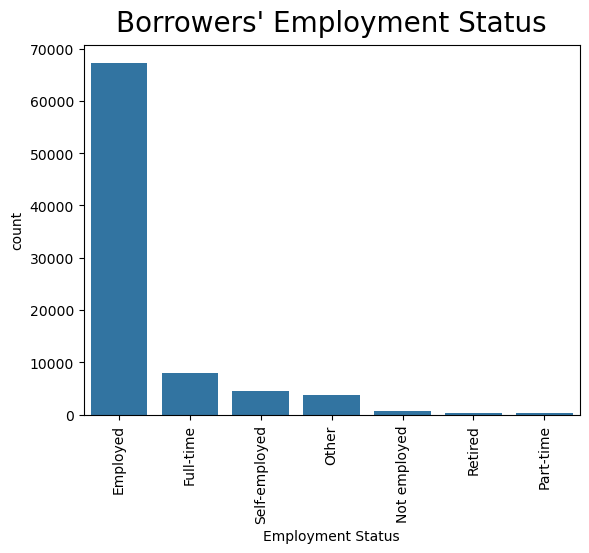

## Income Verifiable

> More than 90% of borrowers' income is verifiable. This is a contributory factor why more than 95% of the loans are funded.

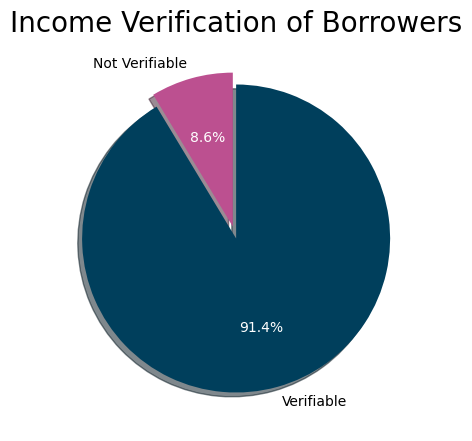

## Average Credit Score

> The Average Credit Score of borrowers are all above minimum Score of 600. This is also a contributory factor why more than 95% of the loans are funded.

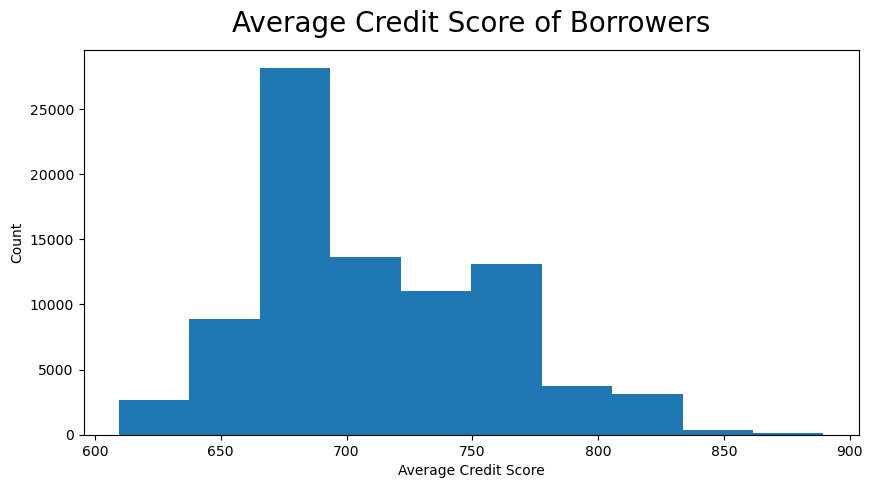

## Borrower APR

> More than 80% of borrowers APR is above 14%. This also affects loan funding as APR of 14% and above is good for lenders.

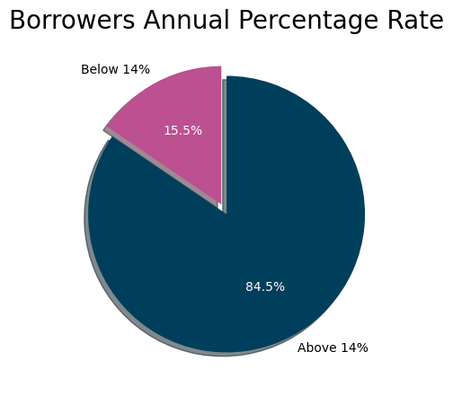

## Loan Date

> There was low application in 2010; as this is the year US begins to recover from the Great Recession (2007 -2009) and most household are trying to payoff accumulated debts. However, there is appreciable increase in loan application from 2010 to 2013. There was a rapid increase in the number in 2014. This is due to the fact that the total number of jobs in this year returns to its level before recession in 2007.

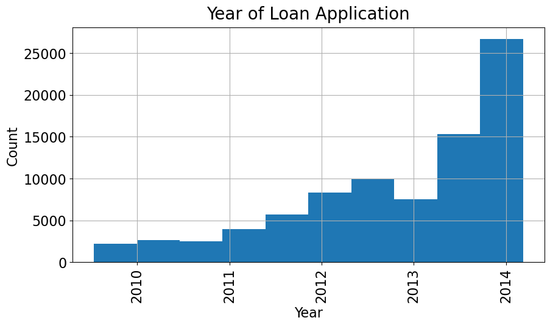

## Term of Repayment

> Over 60% of borrowers stated to repay their loan in 36 months (3 years) whereas very few stated 12 months (1 year). This is related to the actual amount requested. Large number of borrowers requested for \$10,000 and stated to repay less than \\$500 monthly. This is about 10% of monthly income of those earning an average of \$5,000 monthly (average monthly income of those earning between \\$50,000 and \$75,000 annually).

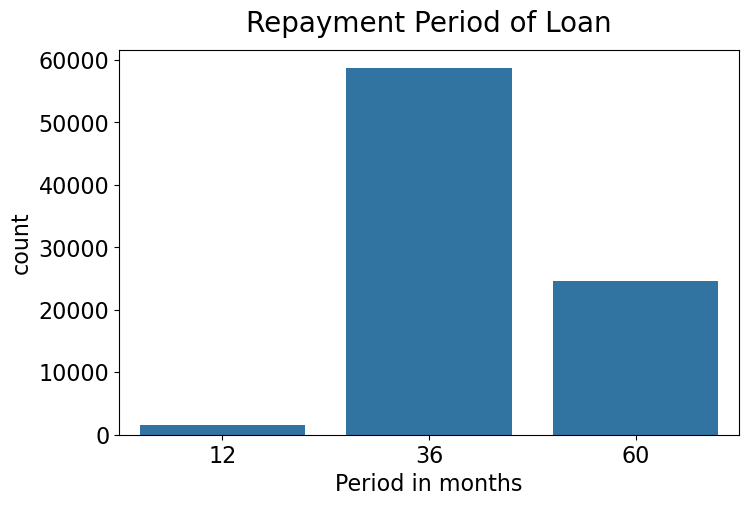

## Borrowers Category (Occupation)

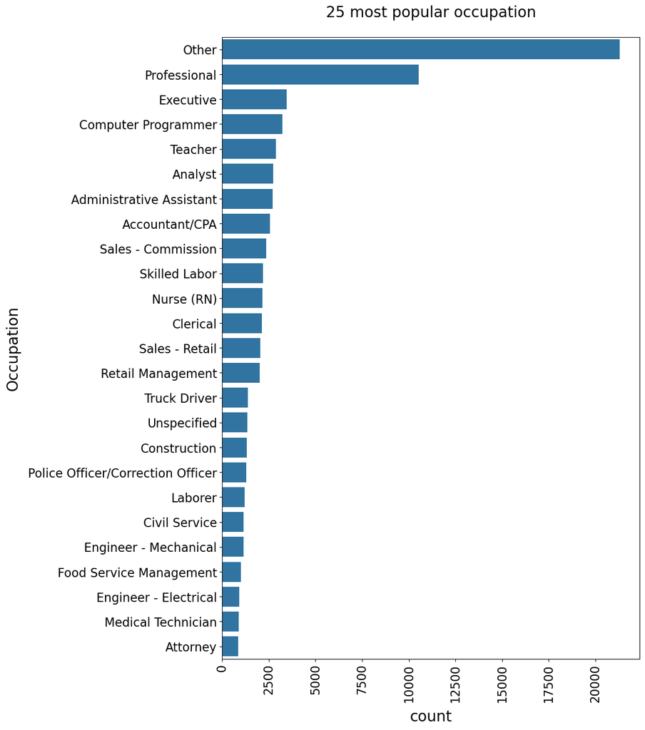

## Listing Category (Loan Purpose)

> More than 60% of the borrowers need the loan for debt consolidation. However, few of them need the loan for wedding, vacation, study, among others.

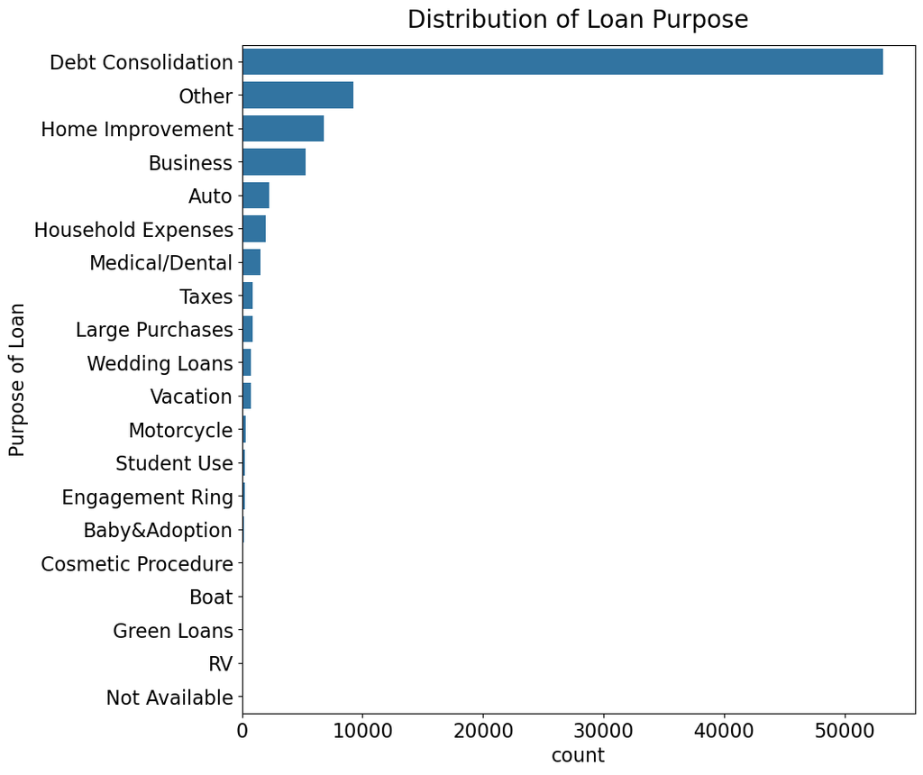

## Loan Amount vs. Year

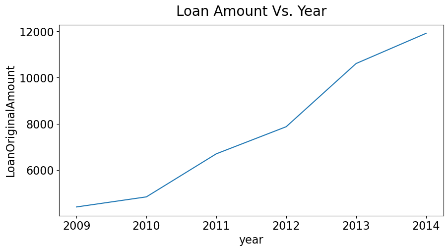

## Relation between Borrower Rate, Year and Ownership of House

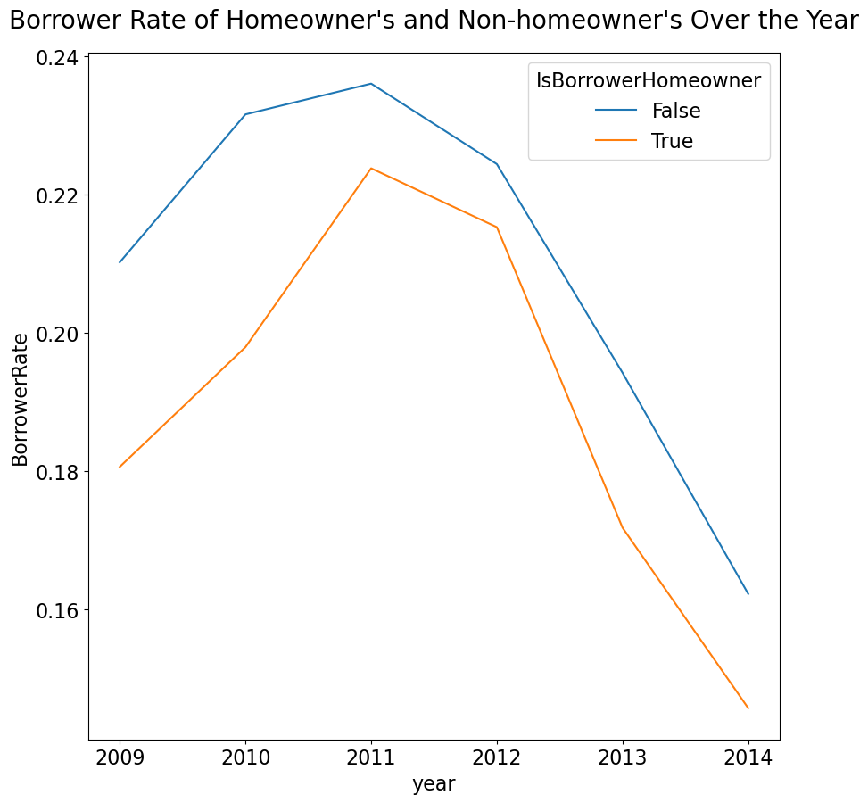